# BeerRadar - Data Incubator Project Proposal

Yue Jin

May 16, 2018

### 1. About Me:

[My Resume in PDF format](https://yjin910517.github.io/data_incubator/resume.pdf)

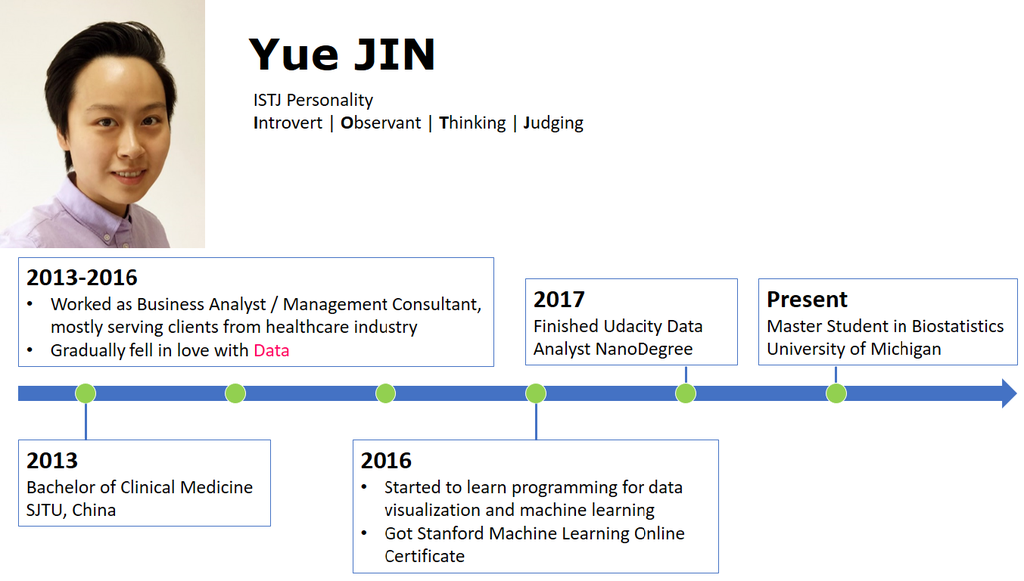

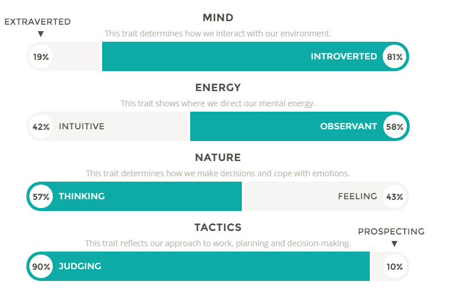

### 2. Project Summary:

**“BeerRadar”**

- To build a beer recommendation App for craft beer lovers
- Use open data scraped from [BeerAdvocate.com](https://www.beeradvocate.com/)
- Leverage existing recommendation algorithm such as matrix factorization and collaborative filter

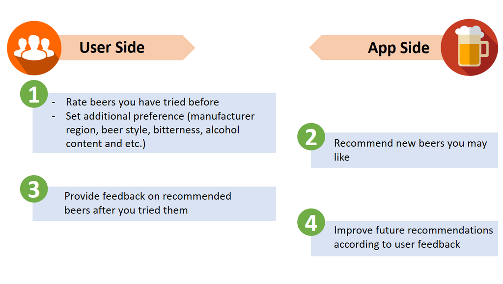

Core Function of BeerRadar

### 3. Motivation:

**A Hobby for me:**

- Personally, I love craft beer
- From 2016 to present, I tasted **152** different beers

**Market Opportunity:**

- Huge user base: 4.71M monthly users of BeerAdvocate.com, 2.99M monthly users of Ratebeer.com, 3.07M monthly users of Untappd.com [(source)](https://craftbeerinsandiego.com/blog/ratebeerisdeadlongliveuntappd)
- Business model successed in similar field: Recommendation Algorithm + Product Merchandise for wine - [BrightCellar](https://www.brightcellars.com/)

### 4. Dataset Description

The data was scraped from [BeerAdvocate.com](https://www.beeradvocate.com/) via Python package [BeautifulSoup](https://www.crummy.com/software/BeautifulSoup/).

The full dataset includes:

- **104** Beer Styles
- **13K** Breweries from around the world
- **200K** Beer items
- **7 Million+** Ratings from **300K+** Users

Estimated data size is ~3 GB.

*Detail data scraping source code can be found on my github [here](https://github.com/yjin910517/data_incubator/blob/master/data_scraping_cleaning/data_scraping.ipynb)*

### 5. Algorithm Test Run:

#### 5.1 Data Subset:

I subsetted the dataset by following criteria to perform an algorithm test run:

- Users who submitted >100 ratings & Beers with >1000 ratings
- **2.2 Million** ratings from **9000 Users** on **1300 Beers**

*Data cleaning code can be found [here](https://github.com/yjin910517/data_incubator/blob/master/data_scraping_cleaning/top_rated/data_cleaning.ipynb)*

#### 5.2 Descriptive Data Analysis:

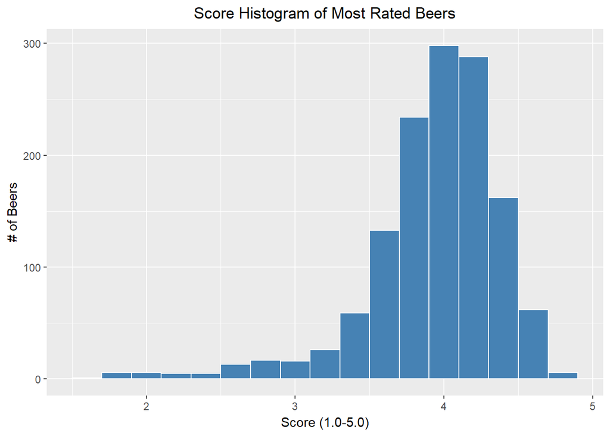

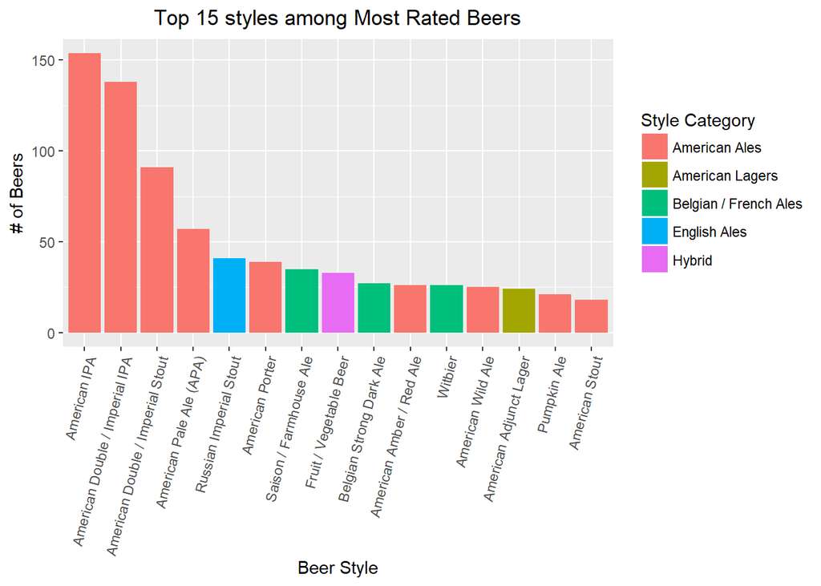

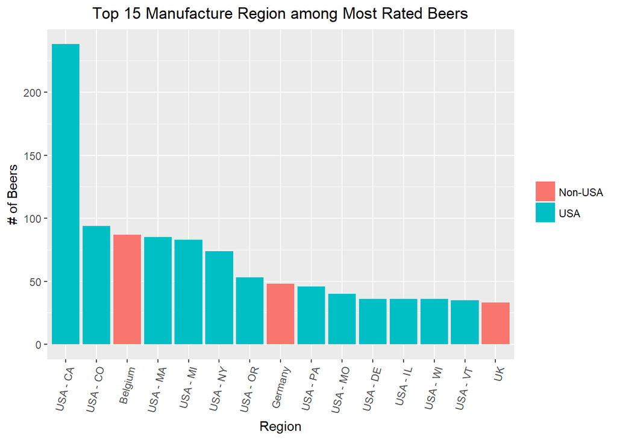

#### 5.3 Result:

SVD matrix factorization implemented with Python [Surprise package](http://surprise.readthedocs.io/en/stable/index.html).

*My Python code can be found [here](https://github.com/yjin910517/data_incubator/blob/master/surprise_basic_model.ipynb)*

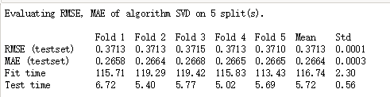

RMSE(Root Mean Square Error) for a 5-fold cross validation is **0.37**, MAE(Mean Absolute Error) is **0.27**, which can be considered as a good performance under the beer rating scale of 5.

**The performance can be further improved from multiple aspects:**

- Parameter tuning for current algorithm
- Leverage text features extracted from textual comments
- Incorporate popularity based/content based algorithms

### 6. Additional functions:

On top of the core functions described above, following functions can be added:

- Beer food pairing recommendation
- Link with purchase (price comparison and etc.)

Potential Dataset expansion:

- [Untappd.com](https://untappd.com/)
- [Ratebeer.com](https://www.ratebeer.com/)

### 7. Potential challenges:

**(AKA why I need the help from Data Incubator)**

- Handle and store big datasets
  - Data wrangling
  - Efficiency of algorithm
- Real time data source update
- User interface design